# A Machine Learning Model using Tensorflow to Describe the Market Price of Cryptocurrencies

### Statistical Testing

Using an **Ordinary Least Squares Regression** on a single predictor, we can model the relationship between the feature and the label with a straight line. Extending this concept to a **Multiple Regression**, we can fit a $p$-dimensional hyperplane to our $p$ predictors.

We can display this for two featured variables in a three dimensional plot.

```python
# Set chosen Features/Predictors
X = predictData.fillna(method='bfill')
X = X.fillna(method='pad')
feat = X
```

```python
# Set Label
y = labelData.fillna(method='bfill')
targ = y
```

The multiple regression model describes the response as a weighted sum of the predictors:

$Price = \beta_0 + \beta_1 \times NetworkDifficulty + \beta_2 \times MyWalletNumUsers + \beta_3 \times BlockchanSize + ... + \beta_n \times MarketDemand $

This model can be visualized as a 2-d plane in 3-d space:

```python
## fit a OLS model with intercept on TV and Radio
X = sm.add_constant(X)
```

```python
est = sm.OLS(y, exog=X, missing="drop").fit()
est.params
```

```
const      1.571949e+02
diffy      8.969247e-11
mwnus     -1.915404e-05
blchs     -7.952586e-03
hrate     -1.431902e-05
cptrv      4.423328e-02
ntrat      5.782972e-06
mirev      1.638519e-05
cptra      1.961113e+00
trvou     -1.663398e-08
etrvu      2.884371e-08
trfus     -1.699963e-05
mktcp      5.632703e-08
gld       -2.663539e-02
crude      1.309110e-02
usd       -1.537265e+00
sp500     -1.037886e-02
bitcoin    1.441238e-04
dtype: float64
```

```
Text(0.5,0,'cptrv')
```

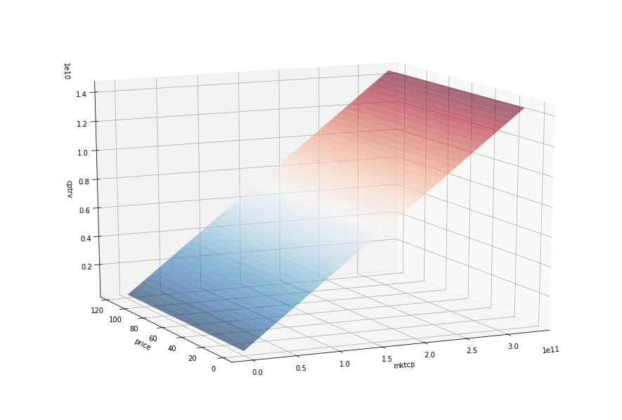

```python
from mpl_toolkits.mplot3d import Axes3D

## Create the 3d plot -- skip reading this
# TV/Radio grid for 3d plot
xx1, xx2 = np.meshgrid(np.linspace(X.mktcp.min(), X.mktcp.max(), 100),
np.linspace(X.cptrv.min(), X.cptrv.max(), 100))
# plot the hyperplane by evaluating the parameters on the grid
Z = est.params[0] + est.params[5] * xx1 + est.params[12] * xx2

# create matplotlib 3d axes
fig = plt.figure(figsize=(12, 8))
ax = Axes3D(fig, azim=-115, elev=15)

# plot hyperplane
surf = ax.plot_surface(xx1, xx2, Z, cmap=plt.cm.RdBu_r, alpha=0.6, linewidth=0)

#bug here
# plot data points - points over the HP are white, points below are black
resid = y - est.predict(X)
ax.scatter(X[resid >= 0].mktcp, X[resid >= 0].cptrv, y[resid >= 0], color='black', alpha=1.0, facecolor='white')
ax.scatter(X[resid < 0].mktcp, X[resid < 0].cptrv, y[resid < 0], color='black', alpha=1.0)

# set axis labels
ax.set_xlabel('mktcp')
ax.set_ylabel('price')
ax.set_zlabel('cptrv')
```

```python
est.summary()
```

OLS Regression Results

| Dep. Variable: | price | R-squared: | 1.000 |
| --- | --- | --- | --- |
| Model: | OLS | Adj. R-squared: | 1.000 |
| Method: | Least Squares | F-statistic: | 2.367e+06 |
| Date: | Sat, 04 Aug 2018 | Prob (F-statistic): | 0.00 |
| Time: | 01:05:02 | Log-Likelihood: | -13391. |
| No. Observations: | 2897 | AIC: | 2.682e+04 |
| Df Residuals: | 2879 | BIC: | 2.692e+04 |
| Df Model: | 17 |  |  |
| Covariance Type: | nonrobust |  |  |

|  | coef | std err | t | P>\|t\| | [0.025 | 0.975] |
| --- | --- | --- | --- | --- | --- | --- |
| const | 157.1949 | 25.662 | 6.125 | 0.000 | 106.876 | 207.513 |
| diffy | 8.969e-11 | 6.08e-12 | 14.743 | 0.000 | 7.78e-11 | 1.02e-10 |
| mwnus | -1.915e-05 | 2.26e-06 | -8.488 | 0.000 | -2.36e-05 | -1.47e-05 |
| blchs | -0.0080 | 0.001 | -10.955 | 0.000 | -0.009 | -0.007 |
| hrate | -1.432e-05 | 7.96e-07 | -17.995 | 0.000 | -1.59e-05 | -1.28e-05 |
| cptrv | 0.0442 | 0.069 | 0.645 | 0.519 | -0.090 | 0.179 |
| ntrat | 5.783e-06 | 4.36e-07 | 13.264 | 0.000 | 4.93e-06 | 6.64e-06 |
| mirev | 1.639e-05 | 1.07e-06 | 15.269 | 0.000 | 1.43e-05 | 1.85e-05 |
| cptra | 1.9611 | 0.068 | 28.850 | 0.000 | 1.828 | 2.094 |
| trvou | -1.663e-08 | 3.44e-09 | -4.832 | 0.000 | -2.34e-08 | -9.88e-09 |
| etrvu | 2.884e-08 | 3.32e-09 | 8.693 | 0.000 | 2.23e-08 | 3.53e-08 |
| trfus | -1.7e-05 | 1.18e-06 | -14.375 | 0.000 | -1.93e-05 | -1.47e-05 |
| mktcp | 5.633e-08 | 1.27e-10 | 444.433 | 0.000 | 5.61e-08 | 5.66e-08 |
| gld | -0.0266 | 0.005 | -5.202 | 0.000 | -0.037 | -0.017 |
| crude | 0.0131 | 0.060 | 0.219 | 0.827 | -0.104 | 0.130 |
| usd | -1.5373 | 0.229 | -6.706 | 0.000 | -1.987 | -1.088 |
| sp500 | -0.0104 | 0.007 | -1.564 | 0.118 | -0.023 | 0.003 |
| bitcoin | 0.0001 | 1.32e-05 | 10.894 | 0.000 | 0.000 | 0.000 |

| Omnibus: | 2433.574 | Durbin-Watson: | 1.274 |
| --- | --- | --- | --- |
| Prob(Omnibus): | 0.000 | Jarque-Bera (JB): | 1241793.367 |
| Skew: | 2.900 | Prob(JB): | 0.00 |
| Kurtosis: | 104.262 | Cond. No. | 6.30e+13 |

Warnings:  
[1] Standard Errors assume that the covariance matrix of the errors is correctly specified.  
[2] The condition number is large, 6.3e+13. This might indicate that there are  
strong multicollinearity or other numerical problems.